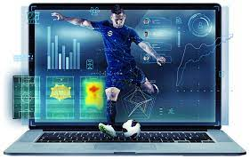

# SPORTS ANALYSIS: FOOTBALL PLAYERS

### This analysis would be concentrated around:-

- ### Data Cleaning and Preprocessing
- ### players and their corresponding skills and attributes that make them stand out.
- ### players and their respective clubs and
- ### players and their countries only.

## Importing the Libraries we'll be using

```python
import numpy as np
import pandas as pd
import matplotlib.pyplot as plt
import seaborn as sns
#Turning off the warnings
import warnings
warnings.filterwarnings('ignore')
```

```python
#To display all the columns of the dataframe
pd.set_option('display.max_columns',70)
```

```python
#Reading the FIFA20 dataset
fifa = pd.read_csv("FIFA22_official_data.csv")
```

## UNDERSTANDING THE DATA

```python
#Dimension of the dataset
fifa.shape
```

```
(16710, 65)
```

16710 datapoints or player details and 65 features/columns

```python
#head of the dataset
fifa.head()
```

|  | ID | Name | Age | Photo | Nationality | Flag | Overall | Potential | Club | Club Logo | Value | Wage | Special | Preferred Foot | International Reputation | Weak Foot | Skill Moves | Work Rate | Body Type | Real Face | Position | Jersey Number | Joined | Loaned From | Contract Valid Until | Height | Weight | Crossing | Finishing | … |
| --- | --- | --- | --- | --- | --- | --- | --- | --- | --- | --- | --- | --- | --- | --- | --- | --- | --- | --- | --- | --- | --- | --- | --- | --- | --- | --- | --- | --- | --- | --- |
| 0 | 212198 | Bruno Fernandes | 26 | https://cdn.sofifa.com/players/212/198/22_60.png | Portugal | https://cdn.sofifa.com/flags/pt.png | 88 | 89 | Manchester United | https://cdn.sofifa.com/teams/11/30.png | €107.5M | €250K | 2341 | Right | 3.0 | 3.0 | 4.0 | High/ High | Unique | Yes | <span class="pos pos18">CAM | 18.0 | Jan 30, 2020 | NaN | 2025 | 179cm | 69kg | 87.0 | 83.0 | … |
| 1 | 209658 | L. Goretzka | 26 | https://cdn.sofifa.com/players/209/658/22_60.png | Germany | https://cdn.sofifa.com/flags/de.png | 87 | 88 | FC Bayern München | https://cdn.sofifa.com/teams/21/30.png | €93M | €140K | 2314 | Right | 4.0 | 4.0 | 3.0 | High/ Medium | Unique | Yes | <span class="pos pos11">LDM | 8.0 | Jul 1, 2018 | NaN | 2026 | 189cm | 82kg | 75.0 | 82.0 | … |
| 2 | 176580 | L. Suárez | 34 | https://cdn.sofifa.com/players/176/580/22_60.png | Uruguay | https://cdn.sofifa.com/flags/uy.png | 88 | 88 | Atlético de Madrid | https://cdn.sofifa.com/teams/240/30.png | €44.5M | €135K | 2307 | Right | 5.0 | 4.0 | 3.0 | High/ Medium | Unique | Yes | <span class="pos pos24">RS | 9.0 | Sep 25, 2020 | NaN | 2022 | 182cm | 83kg | 80.0 | 93.0 | … |
| 3 | 192985 | K. De Bruyne | 30 | https://cdn.sofifa.com/players/192/985/22_60.png | Belgium | https://cdn.sofifa.com/flags/be.png | 91 | 91 | Manchester City | https://cdn.sofifa.com/teams/10/30.png | €125.5M | €350K | 2304 | Right | 4.0 | 5.0 | 4.0 | High/ High | Unique | Yes | <span class="pos pos13">RCM | 17.0 | Aug 30, 2015 | NaN | 2025 | 181cm | 70kg | 94.0 | 82.0 | … |
| 4 | 224334 | M. Acuña | 29 | https://cdn.sofifa.com/players/224/334/22_60.png | Argentina | https://cdn.sofifa.com/flags/ar.png | 84 | 84 | Sevilla FC | https://cdn.sofifa.com/teams/481/30.png | €37M | €45K | 2292 | Left | 2.0 | 3.0 | 4.0 | High/ High | Stocky (170-185) | No | <span class="pos pos7">LB | 19.0 | Sep 14, 2020 | NaN | 2024 | 172cm | 69kg | 87.0 | 66.0 | … |

```python
#columns of the dataframe
fifa.columns
```

```
Index(['ID', 'Name', 'Age', 'Photo', 'Nationality', 'Flag', 'Overall',
       'Potential', 'Club', 'Club Logo', 'Value', 'Wage', 'Special',
       'Preferred Foot', 'International Reputation', 'Weak Foot',
       'Skill Moves', 'Work Rate', 'Body Type', 'Real Face', 'Position',
       'Jersey Number', 'Joined', 'Loaned From', 'Contract Valid Until',
       'Height', 'Weight', 'Crossing', 'Finishing', 'HeadingAccuracy',
       'ShortPassing', 'Volleys', 'Dribbling', 'Curve', 'FKAccuracy',
       'LongPassing', 'BallControl', 'Acceleration', 'SprintSpeed', 'Agility',
       'Reactions', 'Balance', 'ShotPower', 'Jumping', 'Stamina', 'Strength',
       'LongShots', 'Aggression', 'Interceptions', 'Positioning', 'Vision',
       'Penalties', 'Composure', 'Marking', 'StandingTackle', 'SlidingTackle',
       'GKDiving', 'GKHandling', 'GKKicking', 'GKPositioning', 'GKReflexes',
       'Best Position', 'Best Overall Rating', 'Release Clause',
       'DefensiveAwareness'],
      dtype='object')
```

```python
#INFO() function
fifa.info()
```

```
<class 'pandas.core.frame.DataFrame'>
RangeIndex: 16710 entries, 0 to 16709
Data columns (total 65 columns):
 #   Column                    Non-Null Count  Dtype
---  ------                    --------------  -----
 0   ID                        16710 non-null  int64
 1   Name                      16710 non-null  object
 2   Age                       16710 non-null  int64
 3   Photo                     16710 non-null  object
 4   Nationality               16710 non-null  object
 5   Flag                      16710 non-null  object
 6   Overall                   16710 non-null  int64
 7   Potential                 16710 non-null  int64
 8   Club                      16446 non-null  object
 9   Club Logo                 16710 non-null  object
```

[output cut: 57 more lines]

```python
fifa.isnull().sum().sort_values(ascending = False)
```

```
Marking               15818
Loaned From           15578
Release Clause         1749
Joined                 1512
DefensiveAwareness      892
                      ...
ShortPassing              0
Name                      0
FKAccuracy                0
LongPassing               0
Dribbling                 0
Length: 65, dtype: int64
```

I can find there are some missing values for columns such as `Club,Joined`, `LoanedFrom`, `Release Clause`, `Marking`, `Joined` and a few others.

```python
#Some initial stats for the df
fifa.describe()
```

|  | ID | Age | Overall | Potential | Special | International Reputation | Weak Foot | Skill Moves | Jersey Number | Crossing | Finishing | HeadingAccuracy | ShortPassing | Volleys | Dribbling | Curve | FKAccuracy | LongPassing | BallControl | Acceleration | SprintSpeed | Agility | Reactions | Balance | ShotPower | Jumping | Stamina | Strength | LongShots | … |
| --- | --- | --- | --- | --- | --- | --- | --- | --- | --- | --- | --- | --- | --- | --- | --- | --- | --- | --- | --- | --- | --- | --- | --- | --- | --- | --- | --- | --- | --- | --- |
| count | 16710.000000 | 16710.000000 | 16710.000000 | 16710.000000 | 16710.000000 | 16710.000000 | 16710.000000 | 16710.000000 | 16684.000000 | 16710.000000 | 16710.000000 | 16710.000000 | 16710.000000 | 16673.000000 | 16710.000000 | 16673.000000 | 16710.000000 | 16710.000000 | 16710.000000 | 16710.000000 | 16710.000000 | 16673.000000 | 16710.000000 | 16673.000000 | 16710.000000 | 16673.000000 | 16710.000000 | 16710.000000 | 16710.000000 | … |
| mean | 220560.467923 | 25.727409 | 67.646320 | 72.572292 | 1652.497307 | 1.169958 | 3.008199 | 2.475464 | 20.458643 | 52.212448 | 48.725075 | 54.123339 | 61.314423 | 45.652972 | 58.591203 | 50.574522 | 45.074087 | 55.454877 | 61.387433 | 65.684919 | 65.783124 | 65.222875 | 63.592400 | 64.943262 | 60.642190 | 65.896659 | 64.204548 | 66.266008 | 49.989228 | … |
| std | 38496.607959 | 5.048910 | 6.457695 | 5.688085 | 257.271696 | 0.485305 | 0.681742 | 0.791414 | 17.699813 | 17.772348 | 19.401715 | 17.007831 | 13.665353 | 17.828225 | 17.925005 | 18.237536 | 17.596471 | 14.494716 | 15.673348 | 15.005583 | 14.737924 | 14.512499 | 8.594003 | 14.257323 | 12.959795 | 12.285499 | 15.575110 | 12.624115 | 19.082943 | … |
| min | 27.000000 | 16.000000 | 28.000000 | 38.000000 | 571.000000 | 1.000000 | 1.000000 | 1.000000 | 1.000000 | 7.000000 | 3.000000 | 5.000000 | 8.000000 | 4.000000 | 5.000000 | 6.000000 | 4.000000 | 9.000000 | 8.000000 | 13.000000 | 15.000000 | 18.000000 | 28.000000 | 19.000000 | 12.000000 | 22.000000 | 13.000000 | 18.000000 | 4.000000 | … |
| 25% | 203891.250000 | 22.000000 | 63.000000 | 69.000000 | 1525.000000 | 1.000000 | 3.000000 | 2.000000 | 8.000000 | 42.000000 | 34.000000 | 46.000000 | 57.000000 | 33.000000 | 54.000000 | 39.000000 | 33.000000 | 47.000000 | 58.000000 | 58.000000 | 59.000000 | 57.000000 | 58.000000 | 57.000000 | 52.000000 | 59.000000 | 57.000000 | 59.000000 | 37.000000 | … |
| 50% | 229253.000000 | 25.000000 | 68.000000 | 72.000000 | 1687.000000 | 1.000000 | 3.000000 | 2.000000 | 17.000000 | 57.000000 | 53.000000 | 57.000000 | 64.000000 | 48.000000 | 63.500000 | 53.000000 | 44.000000 | 58.000000 | 65.000000 | 68.000000 | 68.000000 | 68.000000 | 64.000000 | 67.000000 | 62.000000 | 67.000000 | 67.000000 | 68.000000 | 55.000000 | … |
| 75% | 245368.750000 | 29.000000 | 72.000000 | 76.000000 | 1826.000000 | 1.000000 | 3.000000 | 3.000000 | 27.000000 | 65.000000 | 64.000000 | 66.000000 | 70.000000 | 59.000000 | 70.000000 | 64.000000 | 59.000000 | 66.000000 | 71.000000 | 76.000000 | 76.000000 | 75.000000 | 69.000000 | 75.000000 | 70.000000 | 74.000000 | 75.000000 | 75.000000 | 65.000000 | … |
| max | 264704.000000 | 54.000000 | 93.000000 | 95.000000 | 2341.000000 | 5.000000 | 5.000000 | 5.000000 | 99.000000 | 94.000000 | 95.000000 | 93.000000 | 94.000000 | 90.000000 | 96.000000 | 94.000000 | 94.000000 | 93.000000 | 96.000000 | 97.000000 | 97.000000 | 96.000000 | 96.000000 | 96.000000 | 95.000000 | 95.000000 | 97.000000 | 97.000000 | 94.000000 | … |

```python
#Copy of our pulled in df
fifa_copy = fifa.copy()
```

## SOME CLEANING AND PREPROCESSING

```python
fifa.head()
```

|  | ID | Name | Age | Photo | Nationality | Flag | Overall | Potential | Club | Club Logo | Value | Wage | Special | Preferred Foot | International Reputation | Weak Foot | Skill Moves | Work Rate | Body Type | Real Face | Position | Jersey Number | Joined | Loaned From | Contract Valid Until | Height | Weight | Crossing | Finishing | … |
| --- | --- | --- | --- | --- | --- | --- | --- | --- | --- | --- | --- | --- | --- | --- | --- | --- | --- | --- | --- | --- | --- | --- | --- | --- | --- | --- | --- | --- | --- | --- |
| 0 | 212198 | Bruno Fernandes | 26 | https://cdn.sofifa.com/players/212/198/22_60.png | Portugal | https://cdn.sofifa.com/flags/pt.png | 88 | 89 | Manchester United | https://cdn.sofifa.com/teams/11/30.png | €107.5M | €250K | 2341 | Right | 3.0 | 3.0 | 4.0 | High/ High | Unique | Yes | <span class="pos pos18">CAM | 18.0 | Jan 30, 2020 | NaN | 2025 | 179cm | 69kg | 87.0 | 83.0 | … |
| 1 | 209658 | L. Goretzka | 26 | https://cdn.sofifa.com/players/209/658/22_60.png | Germany | https://cdn.sofifa.com/flags/de.png | 87 | 88 | FC Bayern München | https://cdn.sofifa.com/teams/21/30.png | €93M | €140K | 2314 | Right | 4.0 | 4.0 | 3.0 | High/ Medium | Unique | Yes | <span class="pos pos11">LDM | 8.0 | Jul 1, 2018 | NaN | 2026 | 189cm | 82kg | 75.0 | 82.0 | … |
| 2 | 176580 | L. Suárez | 34 | https://cdn.sofifa.com/players/176/580/22_60.png | Uruguay | https://cdn.sofifa.com/flags/uy.png | 88 | 88 | Atlético de Madrid | https://cdn.sofifa.com/teams/240/30.png | €44.5M | €135K | 2307 | Right | 5.0 | 4.0 | 3.0 | High/ Medium | Unique | Yes | <span class="pos pos24">RS | 9.0 | Sep 25, 2020 | NaN | 2022 | 182cm | 83kg | 80.0 | 93.0 | … |
| 3 | 192985 | K. De Bruyne | 30 | https://cdn.sofifa.com/players/192/985/22_60.png | Belgium | https://cdn.sofifa.com/flags/be.png | 91 | 91 | Manchester City | https://cdn.sofifa.com/teams/10/30.png | €125.5M | €350K | 2304 | Right | 4.0 | 5.0 | 4.0 | High/ High | Unique | Yes | <span class="pos pos13">RCM | 17.0 | Aug 30, 2015 | NaN | 2025 | 181cm | 70kg | 94.0 | 82.0 | … |
| 4 | 224334 | M. Acuña | 29 | https://cdn.sofifa.com/players/224/334/22_60.png | Argentina | https://cdn.sofifa.com/flags/ar.png | 84 | 84 | Sevilla FC | https://cdn.sofifa.com/teams/481/30.png | €37M | €45K | 2292 | Left | 2.0 | 3.0 | 4.0 | High/ High | Stocky (170-185) | No | <span class="pos pos7">LB | 19.0 | Sep 14, 2020 | NaN | 2024 | 172cm | 69kg | 87.0 | 66.0 | … |

- I am going to delete some `columns` which might not be adding any value adds to our analysis going forward.
- All the url columns and index columns we will try removing right now.

```python
#Dropping some of the columns - ID, Photo, Flag, Club Logo
fifa.drop(['ID','Photo','Flag','Club Logo'],axis=1,inplace=True)
```

```python
#Dropping Real Face column
fifa.drop(['Real Face'],axis=1,inplace=True)
```

```python
#Filtering for rows which have Loaned From column not NULL
fifa.loc[~fifa['Loaned From'].isnull()][:5]
```

|  | Name | Age | Nationality | Overall | Potential | Club | Value | Wage | Special | Preferred Foot | International Reputation | Weak Foot | Skill Moves | Work Rate | Body Type | Position | Jersey Number | Joined | Loaned From | Contract Valid Until | Height | Weight | Crossing | Finishing | HeadingAccuracy | ShortPassing | Volleys | Dribbling | Curve | … |
| --- | --- | --- | --- | --- | --- | --- | --- | --- | --- | --- | --- | --- | --- | --- | --- | --- | --- | --- | --- | --- | --- | --- | --- | --- | --- | --- | --- | --- | --- | --- |
| 9 | A. Griezmann | 30 | France | 85 | 85 | Atlético de Madrid | €53M | €220K | 2259 | Left | 4.0 | 3.0 | 4.0 | Medium/ Medium | Unique | <span class="pos pos26">LS | 8.0 | NaN | <a href="/team/241/fc-barcelona/">FC Barcelona... | Jun 30, 2022 | 176cm | 73kg | 83.0 | 84.0 | 83.0 | 84.0 | 86.0 | 85.0 | 86.0 | … |
| 43 | Saúl | 26 | Spain | 82 | 85 | Chelsea | €39.5M | €68K | 2199 | Left | 3.0 | 4.0 | 3.0 | Medium/ Medium | Lean (170-185) | <span class="pos pos28">SUB | 17.0 | NaN | <a href="/team/240/atletico-de-madrid/">Atléti... | Jun 30, 2022 | 184cm | 75kg | 69.0 | 76.0 | 83.0 | 84.0 | 76.0 | 80.0 | 73.0 | … |
| 72 | A. Florenzi | 30 | Italy | 81 | 81 | AC Milan | €22M | €58K | 2178 | Right | 3.0 | 4.0 | 3.0 | High/ Medium | Unique | <span class="pos pos28">SUB | 25.0 | NaN | <a href="/team/52/roma/">Roma</a> | Jun 30, 2022 | 173cm | 67kg | 77.0 | 73.0 | 70.0 | 83.0 | 85.0 | 75.0 | 73.0 | … |
| 121 | M. Pjanić | 31 | Bosnia and Herzegovina | 82 | 82 | Beşiktaş JK | €25M | €155K | 2147 | Right | 3.0 | 4.0 | 3.0 | Medium/ Medium | Normal (170-185) | <span class="pos pos13">RCM | 15.0 | NaN | <a href="/team/241/fc-barcelona/">FC Barcelona... | Jun 30, 2022 | 178cm | 72kg | 80.0 | 56.0 | 60.0 | 84.0 | 72.0 | 81.0 | 86.0 | … |
| 155 | J. Kucka | 34 | Slovakia | 77 | 77 | Watford | €4.9M | €33K | 2135 | Right | 2.0 | 4.0 | 3.0 | High/ Medium | Normal (185+) | <span class="pos pos11">LDM | 33.0 | NaN | <a href="/team/50/parma/">Parma</a> | Jun 30, 2022 | 186cm | 84kg | 68.0 | 68.0 | 75.0 | 76.0 | 69.0 | 75.0 | 68.0 | … |

You can find some of the Loaned players in the list above.  
Players like Griezmann and Pjanic who are on loan from Barcelona to Atletico de Madrid and Besiktas respectively.

I guess it would be better in this case not to handle the missing values for the columns, because we might end up missing out so many players in that case.  
For columns such as `Loaned From` might be many for so many players as well, since it would be a direct contract with the player.

- ### PLAYER VALUE AND WAGE
- Checking whether all values are defined in Euros or not

```python
fifa.loc[fifa['Value'].str.startswith('€')].shape[0]
```

```
16710
```

### Checking the same for Wages.

```python
fifa.loc[fifa['Wage'].str.startswith('€')].shape[0]
```

```
16710
```

So the Value and Wage of all the players are defined in Euros and also object type, which we can try converting accordingly and try making it as a numeric column.

```python
#Splitting the value column to get just the numeric
fifa['Value'] = fifa['Value'].str.split('€')
fifa['Value'] = fifa['Value'].apply(lambda x:x[1])
```

```python
#Splitting the wage column to get just the numeric
fifa['Wage'] = fifa['Wage'].str.split('€')
fifa['Wage'] = fifa['Wage'].apply(lambda x:x[1])
```

```python
#Converting the player value in thousand Euros to Million Euros and then stripping the end denote.
fifa_value_K = fifa.loc[fifa['Value'].str.endswith('K')]
fifa_value_K['Value'] = fifa_value_K['Value'].apply(lambda x: x[:-1])
fifa_value_K['Value'] = fifa_value_K['Value'].astype('float64')
fifa_value_K['Value'] = fifa_value_K['Value'] / 1000
```

```python
#Stripping the end denote for Million Euros Player value
fifa_value_M = fifa.loc[fifa['Value'].str.endswith('M')]
fifa_value_M['Value'] = fifa_value_M['Value'].apply(lambda x: x[:-1])
fifa_value_M['Value'] = fifa_value_M['Value'].astype('float64')
```

```python
#Converting the player wage in thousand Euros to Million Euros and then stripping the end denote.
fifa_value_K['Wage'] = fifa_value_K['Wage'].apply(lambda x: x[:-1] if x.endswith('K') else x)
fifa_value_K['Wage'] = fifa_value_K['Wage'].astype('float64')
fifa_value_K['Wage'] = fifa_value_K['Wage'] / 1000
```

```python
fifa_value_M.loc[fifa_value_M['Wage'].str.endswith("M")]
```

|  | Name | Age | Nationality | Overall | Potential | Club | Value | Wage | Special | Preferred Foot | International Reputation | Weak Foot | Skill Moves | Work Rate | Body Type | Position | Jersey Number | Joined | Loaned From | Contract Valid Until | Height | Weight | Crossing | Finishing | HeadingAccuracy | ShortPassing | Volleys | Dribbling | Curve | … |
| --- | --- | --- | --- | --- | --- | --- | --- | --- | --- | --- | --- | --- | --- | --- | --- | --- | --- | --- | --- | --- | --- | --- | --- | --- | --- | --- | --- | --- | --- | --- |

We can find that there are no more players who are having values and wages in euros having wages also in Millions. So we will go with thousand converted to millions

```python
#Converting the player wage in thousand Euros to Million Euros and then stripping the end denote.
fifa_value_M['Wage'] = fifa_value_M['Wage'].apply(lambda x: x[:-1] if x.endswith('K') else x)
fifa_value_M['Wage'] = fifa_value_M['Wage'].astype('float64')
fifa_value_M['Wage'] = fifa_value_M['Wage'] / 1000
```

```python
#Concatenating both the splitted up dataframes
fifa2 = pd.concat([fifa_value_M,fifa_value_K])
```

```python
fifa2.shape
```

```
(16366, 60)
```

It looks like the resultant dataframe `fifa2` after our preprocessing, is having less number of records than our initial dataframe. These are records/rows that were having player Values provided as 0 or any other value which were neither in thousands nor Millions. We will proceed with this dataset forour analysis.

```python
fifa2[fifa2['Value']==194]["Name"]
```

```
82    K. Mbappé
Name: Name, dtype: object
```

```python
fifa2['Value'] = pd.to_numeric(fifa2['Value'])
fifa2['Wage'] = pd.to_numeric(fifa2['Wage'])
```

### CLEANING THE POSITION FEATURE

We can find some HTML code getting in(probably when the data is scrapped) with the Position column. We will clean those.

```python
fifa2['Position'] = fifa2['Position'].str.split(">")
fifa2['Position'] = fifa2['Position'].apply(lambda x:x[1])
```

```python
fifa2.head()
```

|  | Name | Age | Nationality | Overall | Potential | Club | Value | Wage | Special | Preferred Foot | International Reputation | Weak Foot | Skill Moves | Work Rate | Body Type | Position | Jersey Number | Joined | Loaned From | Contract Valid Until | Height | Weight | Crossing | Finishing | HeadingAccuracy | ShortPassing | Volleys | Dribbling | Curve | … |
| --- | --- | --- | --- | --- | --- | --- | --- | --- | --- | --- | --- | --- | --- | --- | --- | --- | --- | --- | --- | --- | --- | --- | --- | --- | --- | --- | --- | --- | --- | --- |
| 0 | Bruno Fernandes | 26 | Portugal | 88 | 89 | Manchester United | 107.5 | 0.250 | 2341 | Right | 3.0 | 3.0 | 4.0 | High/ High | Unique | CAM | 18.0 | Jan 30, 2020 | NaN | 2025 | 179cm | 69kg | 87.0 | 83.0 | 64.0 | 91.0 | 87.0 | 83.0 | 87.0 | … |
| 1 | L. Goretzka | 26 | Germany | 87 | 88 | FC Bayern München | 93.0 | 0.140 | 2314 | Right | 4.0 | 4.0 | 3.0 | High/ Medium | Unique | LDM | 8.0 | Jul 1, 2018 | NaN | 2026 | 189cm | 82kg | 75.0 | 82.0 | 86.0 | 86.0 | 69.0 | 84.0 | 76.0 | … |
| 2 | L. Suárez | 34 | Uruguay | 88 | 88 | Atlético de Madrid | 44.5 | 0.135 | 2307 | Right | 5.0 | 4.0 | 3.0 | High/ Medium | Unique | RS | 9.0 | Sep 25, 2020 | NaN | 2022 | 182cm | 83kg | 80.0 | 93.0 | 84.0 | 83.0 | 90.0 | 83.0 | 86.0 | … |
| 3 | K. De Bruyne | 30 | Belgium | 91 | 91 | Manchester City | 125.5 | 0.350 | 2304 | Right | 4.0 | 5.0 | 4.0 | High/ High | Unique | RCM | 17.0 | Aug 30, 2015 | NaN | 2025 | 181cm | 70kg | 94.0 | 82.0 | 55.0 | 94.0 | 82.0 | 88.0 | 85.0 | … |
| 4 | M. Acuña | 29 | Argentina | 84 | 84 | Sevilla FC | 37.0 | 0.045 | 2292 | Left | 2.0 | 3.0 | 4.0 | High/ High | Stocky (170-185) | LB | 19.0 | Sep 14, 2020 | NaN | 2024 | 172cm | 69kg | 87.0 | 66.0 | 58.0 | 82.0 | 68.0 | 87.0 | 88.0 | … |

### CLEANING THE WEIGHT COLUMN

```python
fifa2['Weight'] = fifa2['Weight'].apply(lambda x : x[:-3])
fifa2['Weight'] = fifa2['Weight'].astype('int64')
```

## ANALYSIS ON THE PREFERED FOOT

```python
foot = fifa2['Preferred Foot'].value_counts()
foot
```

```
Right    12352
Left      4014
Name: Preferred Foot, dtype: int64
```

As we expected, the Left Footers are fewer! there are only 4014 left footers in our player list.

Let's check the percentage %

```python
foot_right = foot[0]/fifa2['Preferred Foot'].count()*100
foot_left = foot[1]/fifa2['Preferred Foot'].count()*100
foot_df = pd.DataFrame({'Percentage':[foot_right,foot_left]},index=['Right Foot','Left Foot'])
foot_df.style.background_gradient(cmap='Purples')
```

|  | Percentage |
| --- | --- |
| Right Foot | 75.473543 |
| Left Foot | 24.526457 |

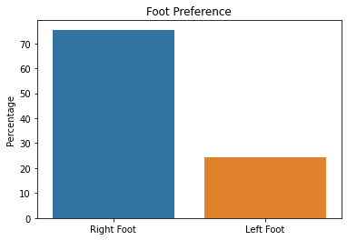

```python
#Barplot for the classes
plt.title("Foot Preference")
sns.barplot(x=foot_df.index,y=foot_df['Percentage'])
plt.show()
```

This clearly indicates the dominance of Right footers in the Football. There are just a small percentage of Left Footers, hence their importance.

## AVERAGE AGE OF ALL THE PLAYERS

```python
fifa2.Age.mean()
```

```
25.633752902358548
```

## The most used Jersey Number

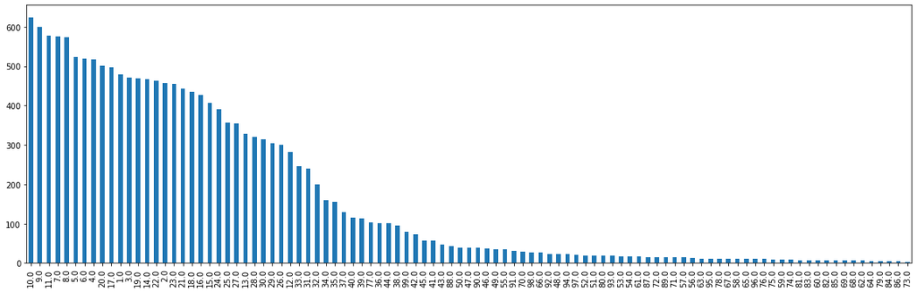

```python
plt.figure(figsize = (20, 6))
fifa2["Jersey Number"].value_counts().plot(kind='bar');
```

- **`Number 10` is the most worn number!!!**

## TOP 5 MOST VALUABLE PLAYERS

```python
fifa2.sort_values(['Value'],ascending=False)[:5]
```

|  | Name | Age | Nationality | Overall | Potential | Club | Value | Wage | Special | Preferred Foot | International Reputation | Weak Foot | Skill Moves | Work Rate | Body Type | Position | Jersey Number | Joined | Loaned From | Contract Valid Until | Height | Weight | Crossing | Finishing | HeadingAccuracy | ShortPassing | Volleys | Dribbling | Curve | … |
| --- | --- | --- | --- | --- | --- | --- | --- | --- | --- | --- | --- | --- | --- | --- | --- | --- | --- | --- | --- | --- | --- | --- | --- | --- | --- | --- | --- | --- | --- | --- |
| 82 | K. Mbappé | 22 | France | 91 | 95 | Paris Saint-Germain | 194.0 | 0.23 | 2175 | Right | 4.0 | 4.0 | 5.0 | High/ Low | Unique | ST | 7.0 | Jul 1, 2018 | NaN | 2022 | 182cm | 7 | 78.0 | 93.0 | 72.0 | 85.0 | 83.0 | 93.0 | 80.0 | … |
| 251 | E. Haaland | 20 | Norway | 88 | 93 | Borussia Dortmund | 137.5 | 0.11 | 2102 | Left | 4.0 | 3.0 | 3.0 | High/ High | Unique | RS | 9.0 | Jan 1, 2020 | NaN | 2024 | 194cm | 9 | 47.0 | 94.0 | 69.0 | 77.0 | 88.0 | 78.0 | 77.0 | … |
| 39 | H. Kane | 27 | England | 90 | 90 | Tottenham Hotspur | 129.5 | 0.24 | 2205 | Right | 4.0 | 5.0 | 3.0 | High/ High | Unique | ST | 10.0 | Jul 28, 2010 | NaN | 2024 | 188cm | 8 | 80.0 | 94.0 | 86.0 | 85.0 | 88.0 | 83.0 | 83.0 | … |
| 64 | Neymar Jr | 29 | Brazil | 91 | 91 | Paris Saint-Germain | 129.0 | 0.27 | 2183 | Right | 5.0 | 5.0 | 5.0 | High/ Medium | Unique | LW | 10.0 | Aug 3, 2017 | NaN | 2025 | 175cm | 6 | 85.0 | 83.0 | 63.0 | 86.0 | 86.0 | 95.0 | 88.0 | … |
| 3 | K. De Bruyne | 30 | Belgium | 91 | 91 | Manchester City | 125.5 | 0.35 | 2304 | Right | 4.0 | 5.0 | 4.0 | High/ High | Unique | RCM | 17.0 | Aug 30, 2015 | NaN | 2025 | 181cm | 7 | 94.0 | 82.0 | 55.0 | 94.0 | 82.0 | 88.0 | 85.0 | … |

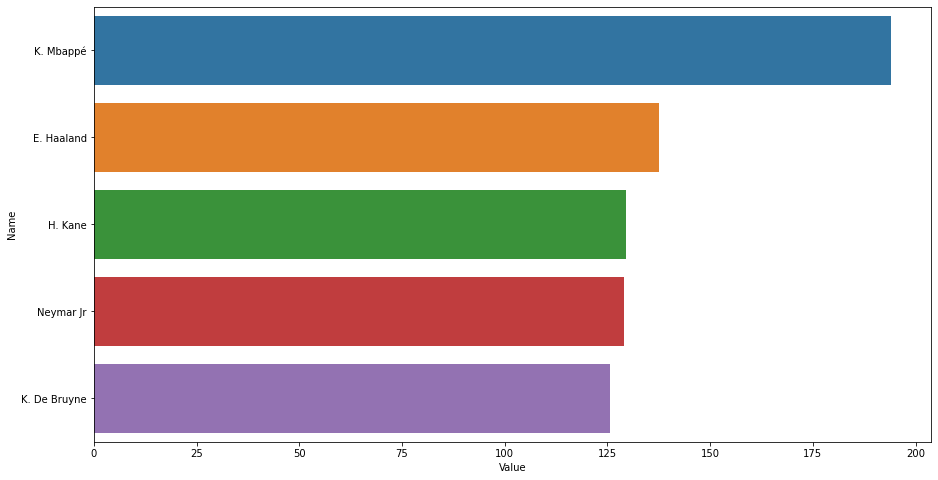

```python
top_value = fifa2.sort_values(by = ['Value'], ascending = False)
plt.figure(figsize = (15, 8))
sns.barplot(x = top_value ["Value"], y = top_value["Name"][:5]);
```

## TOP 10 PLAYERS WITH HIGHEST OVERALL RATINGS

```python
fifa_overall = fifa2.sort_values(['Overall'],ascending=False)[:10]
fifa_overall[['Name','Overall','Potential','Club','Preferred Foot','Position', 'Nationality']].style.background_gradient(cmap='Reds')
```

|  | Name | Overall | Potential | Club | Preferred Foot | Position | Nationality |
| --- | --- | --- | --- | --- | --- | --- | --- |
| 29 | L. Messi | 93 | 93 | Paris Saint-Germain | Left | RW | Argentina |
| 33 | R. Lewandowski | 92 | 92 | FC Bayern München | Right | ST | Poland |
| 64 | Neymar Jr | 91 | 91 | Paris Saint-Germain | Right | LW | Brazil |
| 3 | K. De Bruyne | 91 | 91 | Manchester City | Right | RCM | Belgium |
| 36 | Cristiano Ronaldo | 91 | 91 | Manchester United | Right | ST | Portugal |
| 82 | K. Mbappé | 91 | 95 | Paris Saint-Germain | Right | ST | France |
| 14244 | J. Oblak | 91 | 93 | Atlético de Madrid | Right | GK | Slovenia |
| 39 | H. Kane | 90 | 90 | Tottenham Hotspur | Right | ST | England |
| 12350 | M. Neuer | 90 | 90 | FC Bayern München | Right | GK | Germany |
| 13890 | M. ter Stegen | 90 | 92 | FC Barcelona | Right | GK | Germany |

These are the top 10 ->  
`L. Messi`,`R. Lewandowski`,`Neymar Jr`,`K. De Bruyne`,`Cristiano Ronaldo`,`K. Mbappé`,`J. Oblak`,`H. Kane`,`M. ter Stegen`,`M. Neuer`  
Interesting FACT ---->>> 2 German Goalkeepers in the top 10 in `M. ter Stegen` and `M. Neuer`.  
And also **I WONDER HOW PSG IS LOSING SO MANY MATCHES -> 3 OF THEIR BEST ARE IN THE TOP10 TOO**

## TOP 10 PLAYERS WITH HIGHEST POTENTIAL

```python
fifa_potential = fifa2.sort_values(['Potential'],ascending=False)[:10]
fifa_potential[['Name','Overall','Potential','Club','Preferred Foot','Position']].style.background_gradient(cmap='Reds')
```

|  | Name | Overall | Potential | Club | Preferred Foot | Position |
| --- | --- | --- | --- | --- | --- | --- |
| 82 | K. Mbappé | 91 | 95 | Paris Saint-Germain | Right | ST |
| 251 | E. Haaland | 88 | 93 | Borussia Dortmund | Left | RS |
| 29 | L. Messi | 93 | 93 | Paris Saint-Germain | Left | RW |
| 14608 | G. Donnarumma | 89 | 93 | Paris Saint-Germain | Right | GK |
| 14244 | J. Oblak | 91 | 93 | Atlético de Madrid | Right | GK |
| 17 | F. de Jong | 87 | 92 | FC Barcelona | Right | RCM |
| 24 | T. Alexander-Arnold | 87 | 92 | Liverpool | Right | RB |
| 33 | R. Lewandowski | 92 | 92 | FC Bayern München | Right | ST |
| 588 | K. Havertz | 84 | 92 | Chelsea | Left | LW |
| 13890 | M. ter Stegen | 90 | 92 | FC Barcelona | Right | GK |

These are the top 10:  
`K. Mbappé`,`E. Haaland`,`L. Messi`,`G. Donnarumma`,`J. Oblak`,`F.de Jong`,`T.Alexander-Arnold`,`R. Lewandowski`,`K. Havertz`,`M. ter Stegen`

We've always been viewing the top guys! We will see the bottom ones now.

## BOTTOM 10 IN POTENTIAL AND OVERALL

```python
fifa2.sort_values(['Overall'],ascending=True)[:10]
```

|  | Name | Age | Nationality | Overall | Potential | Club | Value | Wage | Special | Preferred Foot | International Reputation | Weak Foot | Skill Moves | Work Rate | Body Type | Position | Jersey Number | Joined | Loaned From | Contract Valid Until | Height | Weight | Crossing | Finishing | HeadingAccuracy | ShortPassing | Volleys | Dribbling | Curve | … |
| --- | --- | --- | --- | --- | --- | --- | --- | --- | --- | --- | --- | --- | --- | --- | --- | --- | --- | --- | --- | --- | --- | --- | --- | --- | --- | --- | --- | --- | --- | --- |
| 15999 | 16 E. Redman | 18 | Wales | 44 | 57 | Newport County | 0.05 | 0.002 | 1089 | Right | 1.0 | 2.0 | 2.0 | Medium/ Medium | Stocky (170-185) | RES | 49.0 | Oct 22, 2013 | NaN | 2016 | 184cm | 8 | 26.0 | 16.0 | 42.0 | 37.0 | 15.0 | 20.0 | 22.0 | … |
| 15593 | 18 T. Käßemodel | 28 | Germany | 46 | 46 | FC Erzgebirge Aue | 0.03 | 0.002 | 1174 | Right | 1.0 | 3.0 | 2.0 | Medium/ Medium | Stocky (170-185) | RES | 29.0 | Jul 1, 2016 | NaN | 2018 | 173cm | 7 | 42.0 | 40.0 | 38.0 | 54.0 | 34.0 | 44.0 | 52.0 | … |
| 15685 | 15 T. Fletcher | 19 | England | 46 | 52 | Wycombe Wanderers | 0.02 | 0.002 | 1157 | Right | 1.0 | 2.0 | 2.0 | Medium/ Medium | Lean (170-185) | SUB | 16.0 | Jul 9, 2013 | NaN | 2015 | 183cm | 7 | 21.0 | 25.0 | 41.0 | 25.0 | 24.0 | 27.0 | 24.0 | … |
| 16708 | A. Shaikh | 18 | India | 47 | 67 | ATK Mohun Bagan FC | 0.11 | 0.500 | 754 | Right | 1.0 | 3.0 | 1.0 | Medium/ Medium | Normal (185+) | SUB | 31.0 | Aug 1, 2020 | NaN | 2022 | 186cm | 7 | 13.0 | 8.0 | 10.0 | 22.0 | 8.0 | 10.0 | 11.0 | … |
| 15244 | R. Gallagher | 20 | Republic of Ireland | 47 | 61 | Finn Harps | 0.11 | 0.500 | 1255 | Right | 1.0 | 3.0 | 2.0 | Medium/ Medium | Lean (170-185) | RES | 29.0 | Jan 1, 2018 | NaN | 2021 | 180cm | 7 | 33.0 | 33.0 | 44.0 | 51.0 | 34.0 | 40.0 | 31.0 | … |
| 15283 | Wang Zhen'ao | 21 | China PR | 47 | 57 | Dalian Professional Football Club | 0.11 | 0.002 | 1246 | Right | 1.0 | 3.0 | 2.0 | Medium/ Medium | Normal (170-) | SUB | 34.0 | Sep 22, 2020 | NaN | 2022 | 170cm | 5 | 45.0 | 52.0 | 34.0 | 42.0 | 42.0 | 51.0 | 35.0 | … |
| 14787 | Hu Xingyu | 19 | China PR | 47 | 55 | Chongqing Liangjiang Athletic | 0.10 | 0.800 | 1352 | Right | 1.0 | 2.0 | 2.0 | Low/ Low | Lean (170-185) | SUB | 21.0 | Apr 22, 2021 | NaN | 2025 | 178cm | 6 | 33.0 | 26.0 | 47.0 | 56.0 | 30.0 | 42.0 | 34.0 | … |
| 14720 | N. Saliba | 17 | Canada | 47 | 69 | Club de Foot Montréal | 0.15 | 0.500 | 1363 | Right | 1.0 | 2.0 | 2.0 | Medium/ Medium | Normal (170-185) | RES | 36.0 | Dec 4, 2020 | NaN | 2021 | 173cm | 7 | 33.0 | 28.0 | 43.0 | 51.0 | 31.0 | 45.0 | 30.0 | … |
| 15434 | L. Rudden | 19 | Republic of Ireland | 47 | 60 | Finn Harps | 0.11 | 0.500 | 1210 | Right | 1.0 | 3.0 | 2.0 | Medium/ Medium | Lean (170-185) | RES | 12.0 | Jun 18, 2021 | NaN | 2021 | 173cm | 6 | 29.0 | 49.0 | 40.0 | 38.0 | 34.0 | 42.0 | 36.0 | … |
| 15573 | Wang Shilong | 20 | China PR | 47 | 60 | Guangzhou FC | 0.11 | 0.002 | 1178 | Right | 1.0 | 3.0 | 2.0 | Medium/ High | Lean (170-185) | SUB | 20.0 | Aug 3, 2020 | NaN | 2022 | 177cm | 6 | 25.0 | 17.0 | 40.0 | 30.0 | 26.0 | 23.0 | 22.0 | … |

```python
fifa2.sort_values(['Potential'],ascending=True)[:10]
```

|  | Name | Age | Nationality | Overall | Potential | Club | Value | Wage | Special | Preferred Foot | International Reputation | Weak Foot | Skill Moves | Work Rate | Body Type | Position | Jersey Number | Joined | Loaned From | Contract Valid Until | Height | Weight | Crossing | Finishing | HeadingAccuracy | ShortPassing | Volleys | Dribbling | Curve | … |
| --- | --- | --- | --- | --- | --- | --- | --- | --- | --- | --- | --- | --- | --- | --- | --- | --- | --- | --- | --- | --- | --- | --- | --- | --- | --- | --- | --- | --- | --- | --- |
| 15593 | 18 T. Käßemodel | 28 | Germany | 46 | 46 | FC Erzgebirge Aue | 0.030 | 0.002 | 1174 | Right | 1.0 | 3.0 | 2.0 | Medium/ Medium | Stocky (170-185) | RES | 29.0 | Jul 1, 2016 | NaN | 2018 | 173cm | 7 | 42.0 | 40.0 | 38.0 | 54.0 | 34.0 | 44.0 | 52.0 | … |
| 15733 | 21 M. Wright | 33 | England | 47 | 47 | Crawley Town | 0.025 | 0.001 | 1148 | Left | 1.0 | 1.0 | 2.0 | Low/ Low | Stocky (170-185) | RES | 30.0 | Dec 14, 2020 | NaN | 2021 | 178cm | 8 | 46.0 | 26.0 | 43.0 | 39.0 | 20.0 | 35.0 | 40.0 | … |
| 14188 | J. Russell | 36 | Republic of Ireland | 49 | 49 | Sligo Rovers | 0.015 | 0.500 | 1419 | Right | 1.0 | 3.0 | 3.0 | High/ High | Normal (170-185) | RES | 18.0 | Dec 7, 2018 | NaN | 2021 | 172cm | 7 | 51.0 | 40.0 | 49.0 | 52.0 | 40.0 | 43.0 | 58.0 | … |
| 15027 | 19 B. Barry-Murphy | 39 | Republic of Ireland | 49 | 49 | Rochdale | 0.007 | 0.001 | 1309 | Left | 1.0 | 3.0 | 2.0 | Low/ Low | Lean (185+) | RES | 20.0 | Jul 1, 2010 | NaN | 2022 | 185cm | 7 | 62.0 | 28.0 | 25.0 | 55.0 | 33.0 | 37.0 | 62.0 | … |
| 14304 | Tan Chun Lok | 25 | Hong Kong | 49 | 51 | Guangzhou City | 0.060 | 0.002 | 1408 | Right | 1.0 | 3.0 | 2.0 | Medium/ Low | Lean (170-185) | SUB | 16.0 | Jul 1, 2020 | NaN | 2022 | 174cm | 7 | 43.0 | 37.0 | 48.0 | 57.0 | 33.0 | 41.0 | 38.0 | … |
| 15049 | S. Haokip | 28 | India | 51 | 51 | SC East Bengal FC | 0.060 | 0.500 | 1305 | Right | 1.0 | 3.0 | 2.0 | Medium/ Medium | Normal (170-185) | RES | 18.0 | Sep 7, 2021 | NaN | 2022 | 183cm | 7 | 31.0 | 53.0 | 45.0 | 38.0 | 56.0 | 51.0 | 38.0 | … |
| 16388 | Ma Zhen | 23 | China PR | 48 | 52 | Shanghai Shenhua FC | 0.050 | 0.001 | 964 | Right | 1.0 | 2.0 | 1.0 | Medium/ Medium | Lean (185+) | SUB | 1.0 | Jul 15, 2020 | NaN | 2021 | 196cm | 8 | 12.0 | 13.0 | 11.0 | 13.0 | 14.0 | 11.0 | 12.0 | … |
| 15685 | 15 T. Fletcher | 19 | England | 46 | 52 | Wycombe Wanderers | 0.020 | 0.002 | 1157 | Right | 1.0 | 2.0 | 2.0 | Medium/ Medium | Lean (170-185) | SUB | 16.0 | Jul 9, 2013 | NaN | 2015 | 183cm | 7 | 21.0 | 25.0 | 41.0 | 25.0 | 24.0 | 27.0 | 24.0 | … |
| 15601 | M. McChrystal | 37 | Northern Ireland | 52 | 52 | Derry City | 0.015 | 0.500 | 1172 | Left | 1.0 | 2.0 | 2.0 | Low/ High | Stocky (185+) | SUB | 16.0 | Jul 4, 2019 | NaN | 2021 | 185cm | 8 | 31.0 | 35.0 | 52.0 | 45.0 | 26.0 | 32.0 | 32.0 | … |
| 16203 | K. Singh | 34 | India | 53 | 53 | Chennaiyin FC | 0.015 | 0.500 | 1032 | Right | 1.0 | 2.0 | 1.0 | Medium/ Medium | Lean (170-185) | SUB | 1.0 | Sep 5, 2020 | NaN | 2025 | 181cm | 7 | 14.0 | 13.0 | 17.0 | 23.0 | 17.0 | 20.0 | 14.0 | … |

## Top Rated Players by Nationality

- ### Nigerian Players

```python
fifa2Nigeria = fifa2.loc[fifa2.Nationality=='Nigeria']
fifa2Nigeria.sort_values(['Overall'],ascending=False)[:5]
```

|  | Name | Age | Nationality | Overall | Potential | Club | Value | Wage | Special | Preferred Foot | International Reputation | Weak Foot | Skill Moves | Work Rate | Body Type | Position | Jersey Number | Joined | Loaned From | Contract Valid Until | Height | Weight | Crossing | Finishing | HeadingAccuracy | ShortPassing | Volleys | Dribbling | Curve | … |
| --- | --- | --- | --- | --- | --- | --- | --- | --- | --- | --- | --- | --- | --- | --- | --- | --- | --- | --- | --- | --- | --- | --- | --- | --- | --- | --- | --- | --- | --- | --- |
| 218 | W. Ndidi | 24 | Nigeria | 85 | 88 | Leicester City | 66.5 | 0.120 | 2113 | Right | 1.0 | 4.0 | 3.0 | Medium/ High | Lean (170-185) | LDM | 25.0 | Jan 5, 2017 | NaN | 2024 | 183cm | 7 | 53.0 | 50.0 | 72.0 | 78.0 | 68.0 | 72.0 | 60.0 | … |
| 1425 | V. Osimhen | 22 | Nigeria | 80 | 87 | Napoli | 43.0 | 0.066 | 1961 | Right | 2.0 | 4.0 | 3.0 | High/ Medium | Lean (185+) | ST | 9.0 | Sep 1, 2020 | NaN | 2025 | 185cm | 7 | 64.0 | 85.0 | 78.0 | 69.0 | 75.0 | 74.0 | 63.0 | … |
| 3795 | P. Onuachu | 27 | Nigeria | 79 | 80 | KRC Genk | 20.5 | 0.023 | 1841 | Right | 1.0 | 2.0 | 3.0 | High/ Medium | Normal (185+) | ST | 18.0 | Aug 22, 2019 | NaN | 2024 | 201cm | 9 | 41.0 | 83.0 | 85.0 | 73.0 | 73.0 | 73.0 | 58.0 | … |
| 1826 | K. Iheanacho | 24 | Nigeria | 78 | 82 | Leicester City | 20.5 | 0.083 | 1934 | Left | 1.0 | 3.0 | 4.0 | Medium/ Medium | Normal (185+) | SUB | 14.0 | Aug 3, 2017 | NaN | 2024 | 185cm | 8 | 59.0 | 82.0 | 67.0 | 77.0 | 77.0 | 79.0 | 74.0 | … |
| 338 | V. Moses | 30 | Nigeria | 78 | 78 | Spartak Moskva | 13.5 | 0.056 | 2081 | Right | 2.0 | 4.0 | 4.0 | Medium/ Medium | Normal (170-185) | RM | 8.0 | Jul 2, 2021 | NaN | 2023 | 177cm | 7 | 76.0 | 67.0 | 69.0 | 76.0 | 64.0 | 82.0 | 75.0 | … |

- ### German Players

```python
fifa2_Germany = fifa2.loc[fifa2.Nationality=='Germany']

fifa2_Germany.sort_values(['Overall'],ascending=False)[:5]
```

|  | Name | Age | Nationality | Overall | Potential | Club | Value | Wage | Special | Preferred Foot | International Reputation | Weak Foot | Skill Moves | Work Rate | Body Type | Position | Jersey Number | Joined | Loaned From | Contract Valid Until | Height | Weight | Crossing | Finishing | HeadingAccuracy | ShortPassing | Volleys | Dribbling | Curve | … |
| --- | --- | --- | --- | --- | --- | --- | --- | --- | --- | --- | --- | --- | --- | --- | --- | --- | --- | --- | --- | --- | --- | --- | --- | --- | --- | --- | --- | --- | --- | --- |
| 13890 | M. ter Stegen | 29 | Germany | 90 | 92 | FC Barcelona | 99.0 | 0.250 | 1444 | Right | 4.0 | 4.0 | 1.0 | Medium/ Medium | Unique | GK | 1.0 | Jul 1, 2014 | NaN | 2025 | 187cm | 8 | 18.0 | 14.0 | 11.0 | 61.0 | 14.0 | 21.0 | 18.0 | … |
| 12350 | M. Neuer | 35 | Germany | 90 | 90 | FC Bayern München | 13.5 | 0.086 | 1534 | Right | 5.0 | 4.0 | 1.0 | Medium/ Medium | Unique | GK | 1.0 | Jul 1, 2011 | NaN | 2023 | 193cm | 9 | 15.0 | 13.0 | 25.0 | 60.0 | 11.0 | 30.0 | 14.0 | … |
| 5 | J. Kimmich | 26 | Germany | 89 | 90 | FC Bayern München | 108.0 | 0.160 | 2283 | Right | 4.0 | 4.0 | 3.0 | High/ Medium | Lean (170-185) | RDM | 6.0 | Jul 1, 2015 | NaN | 2025 | 177cm | 7 | 91.0 | 68.0 | 72.0 | 87.0 | 69.0 | 83.0 | 85.0 | … |
| 116 | T. Kroos | 31 | Germany | 88 | 88 | Real Madrid CF | 75.0 | 0.310 | 2148 | Right | 4.0 | 5.0 | 3.0 | Medium/ Medium | Normal (170-185) | LCM | 8.0 | Jul 17, 2014 | NaN | 2023 | 183cm | 7 | 88.0 | 77.0 | 58.0 | 93.0 | 82.0 | 80.0 | 86.0 | … |
| 125 | 17 P. Lahm | 32 | Germany | 88 | 88 | FC Bayern München | 29.5 | 0.200 | 2146 | Right | 4.0 | 3.0 | 3.0 | Medium/ High | Normal (170-) | RB | 21.0 | Nov 1, 2002 | NaN | 2018 | 170cm | 6 | 84.0 | 47.0 | 63.0 | 86.0 | 66.0 | 82.0 | 77.0 | … |

- ### Portuguese players

```python
fifa2Portugal = fifa2.loc[fifa2.Nationality=='Portugal']
fifa2Portugal.sort_values(['Overall'],ascending=False)[:11]
```

|  | Name | Age | Nationality | Overall | Potential | Club | Value | Wage | Special | Preferred Foot | International Reputation | Weak Foot | Skill Moves | Work Rate | Body Type | Position | Jersey Number | Joined | Loaned From | Contract Valid Until | Height | Weight | Crossing | Finishing | HeadingAccuracy | ShortPassing | Volleys | Dribbling | Curve | … |
| --- | --- | --- | --- | --- | --- | --- | --- | --- | --- | --- | --- | --- | --- | --- | --- | --- | --- | --- | --- | --- | --- | --- | --- | --- | --- | --- | --- | --- | --- | --- |
| 36 | Cristiano Ronaldo | 36 | Portugal | 91 | 91 | Manchester United | 45.0 | 0.270 | 2208 | Right | 5.0 | 4.0 | 5.0 | High/ Low | Unique | ST | 7.0 | Aug 27, 2021 | NaN | 2023 | 187cm | 8 | 87.0 | 95.0 | 90.0 | 80.0 | 86.0 | 88.0 | 81.0 | … |
| 0 | Bruno Fernandes | 26 | Portugal | 88 | 89 | Manchester United | 107.5 | 0.250 | 2341 | Right | 3.0 | 3.0 | 4.0 | High/ High | Unique | CAM | 18.0 | Jan 30, 2020 | NaN | 2025 | 179cm | 6 | 87.0 | 83.0 | 64.0 | 91.0 | 87.0 | 83.0 | 87.0 | … |
| 2754 | Rúben Dias | 24 | Portugal | 87 | 91 | Manchester City | 102.5 | 0.170 | 1886 | Right | 3.0 | 4.0 | 2.0 | Medium/ High | Normal (185+) | RCB | 3.0 | Sep 29, 2020 | NaN | 2027 | 187cm | 8 | 54.0 | 29.0 | 87.0 | 81.0 | 32.0 | 64.0 | 46.0 | … |
| 170 | Bernardo Silva | 26 | Portugal | 86 | 86 | Manchester City | 74.0 | 0.200 | 2128 | Left | 2.0 | 3.0 | 4.0 | High/ High | Lean (170-185) | SUB | 20.0 | Jul 1, 2017 | NaN | 2025 | 173cm | 6 | 85.0 | 77.0 | 51.0 | 86.0 | 70.0 | 92.0 | 84.0 | … |
| 21 | João Cancelo | 27 | Portugal | 86 | 87 | Manchester City | 71.5 | 0.185 | 2227 | Right | 3.0 | 4.0 | 4.0 | High/ Medium | Unique | LB | 27.0 | Aug 7, 2019 | NaN | 2025 | 182cm | 7 | 86.0 | 68.0 | 72.0 | 85.0 | 62.0 | 85.0 | 84.0 | … |
| 60 | Ricardo Pereira | 27 | Portugal | 84 | 84 | Leicester City | 40.5 | 0.130 | 2186 | Right | 3.0 | 4.0 | 3.0 | High/ High | Unique | RB | 21.0 | Jun 9, 2018 | NaN | 2023 | 175cm | 7 | 82.0 | 66.0 | 67.0 | 82.0 | 59.0 | 81.0 | 78.0 | … |
| 80 | R. Guerreiro | 27 | Portugal | 84 | 84 | Borussia Dortmund | 40.5 | 0.079 | 2175 | Left | 3.0 | 2.0 | 4.0 | High/ Low | Normal (170-) | LB | 13.0 | Jul 1, 2016 | NaN | 2023 | 170cm | 7 | 84.0 | 77.0 | 43.0 | 88.0 | 79.0 | 88.0 | 85.0 | … |
| 439 | André Silva | 25 | Portugal | 84 | 85 | RB Leipzig | 51.0 | 0.110 | 2062 | Right | 3.0 | 3.0 | 4.0 | Medium/ Medium | Normal (185+) | ST | 33.0 | Jul 2, 2021 | NaN | 2026 | 185cm | 8 | 60.0 | 87.0 | 86.0 | 79.0 | 84.0 | 84.0 | 76.0 | … |
| 421 | João Félix | 21 | Portugal | 83 | 91 | Atlético de Madrid | 82.0 | 0.061 | 2065 | Right | 2.0 | 4.0 | 5.0 | Medium/ Medium | Unique | SUB | 7.0 | Jul 3, 2019 | NaN | 2026 | 181cm | 7 | 73.0 | 79.0 | 69.0 | 80.0 | 81.0 | 86.0 | 82.0 | … |
| 14615 | A. Lopes | 30 | Portugal | 82 | 83 | Olympique Lyonnais | 23.0 | 0.060 | 1376 | Left | 2.0 | 2.0 | 1.0 | Medium/ Medium | Normal (170-185) | GK | 1.0 | Jul 1, 2011 | NaN | 2023 | 184cm | 8 | 19.0 | 18.0 | 16.0 | 32.0 | 13.0 | 15.0 | 15.0 | … |
| 617 | Palhinha | 25 | Portugal | 82 | 87 | Sporting CP | 41.0 | 0.018 | 2033 | Right | 1.0 | 4.0 | 2.0 | Medium/ High | Normal (185+) | CDM | 6.0 | NaN | NaN | NaN | 190cm | 8 | 59.0 | 62.0 | 79.0 | 76.0 | 54.0 | 74.0 | 61.0 | … |

- ### French Players

```python
fifa2France = fifa2.loc[fifa2.Nationality=='France']
fifa2France.sort_values(['Overall'],ascending=False)[:11]
```

|  | Name | Age | Nationality | Overall | Potential | Club | Value | Wage | Special | Preferred Foot | International Reputation | Weak Foot | Skill Moves | Work Rate | Body Type | Position | Jersey Number | Joined | Loaned From | Contract Valid Until | Height | Weight | Crossing | Finishing | HeadingAccuracy | ShortPassing | Volleys | Dribbling | Curve | … |
| --- | --- | --- | --- | --- | --- | --- | --- | --- | --- | --- | --- | --- | --- | --- | --- | --- | --- | --- | --- | --- | --- | --- | --- | --- | --- | --- | --- | --- | --- | --- |
| 82 | K. Mbappé | 22 | France | 91 | 95 | Paris Saint-Germain | 194.0 | 0.230 | 2175 | Right | 4.0 | 4.0 | 5.0 | High/ Low | Unique | ST | 7.0 | Jul 1, 2018 | NaN | 2022 | 182cm | 7 | 78.0 | 93.0 | 72.0 | 85.0 | 83.0 | 93.0 | 80.0 | … |
| 71 | N. Kanté | 30 | France | 90 | 90 | Chelsea | 100.0 | 0.230 | 2179 | Right | 4.0 | 3.0 | 2.0 | Medium/ High | Unique | RCM | 7.0 | Jul 16, 2016 | NaN | 2023 | 168cm | 7 | 68.0 | 65.0 | 54.0 | 82.0 | 56.0 | 79.0 | 49.0 | … |
| 201 | K. Benzema | 33 | France | 89 | 89 | Real Madrid CF | 66.0 | 0.350 | 2116 | Right | 4.0 | 4.0 | 4.0 | Medium/ Medium | Normal (170-185) | CF | 9.0 | Jul 9, 2009 | NaN | 2023 | 185cm | 8 | 75.0 | 90.0 | 89.0 | 86.0 | 86.0 | 87.0 | 81.0 | … |
| 27 | P. Pogba | 28 | France | 87 | 87 | Manchester United | 79.5 | 0.220 | 2222 | Right | 4.0 | 4.0 | 5.0 | High/ Medium | Unique | RDM | 6.0 | Aug 9, 2016 | NaN | 2022 | 191cm | 8 | 77.0 | 75.0 | 74.0 | 88.0 | 84.0 | 88.0 | 85.0 | … |
| 14644 | H. Lloris | 34 | France | 87 | 87 | Tottenham Hotspur | 13.5 | 0.125 | 1372 | Left | 4.0 | 1.0 | 1.0 | Medium/ Medium | Unique | GK | 1.0 | Aug 31, 2012 | NaN | 2022 | 188cm | 8 | 13.0 | 10.0 | 10.0 | 50.0 | 11.0 | 10.0 | 11.0 | … |
| 1228 | K. Coman | 25 | France | 86 | 87 | FC Bayern München | 81.0 | 0.120 | 1974 | Right | 4.0 | 3.0 | 4.0 | Medium/ Medium | Unique | SUB | 11.0 | Aug 30, 2015 | NaN | 2023 | 180cm | 7 | 79.0 | 75.0 | 61.0 | 80.0 | 77.0 | 89.0 | 83.0 | … |
| 1897 | R. Varane | 28 | France | 86 | 88 | Manchester United | 68.5 | 0.180 | 1931 | Right | 3.0 | 3.0 | 2.0 | Medium/ High | Unique | RCB | 19.0 | Jul 27, 2021 | NaN | 2025 | 191cm | 8 | 42.0 | 46.0 | 86.0 | 78.0 | 42.0 | 55.0 | 46.0 | … |
| 9 | A. Griezmann | 30 | France | 85 | 85 | Atlético de Madrid | 53.0 | 0.220 | 2259 | Left | 4.0 | 3.0 | 4.0 | Medium/ Medium | Unique | LS | 8.0 | NaN | <a href="/team/241/fc-barcelona/">FC Barcelona... | Jun 30, 2022 | 176cm | 7 | 83.0 | 84.0 | 83.0 | 84.0 | 86.0 | 85.0 | 86.0 | … |
| 22 | L. Digne | 27 | France | 84 | 84 | Everton | 40.5 | 0.110 | 2227 | Left | 2.0 | 2.0 | 3.0 | High/ Medium | Unique | LB | 12.0 | Aug 1, 2018 | NaN | 2023 | 178cm | 7 | 88.0 | 60.0 | 71.0 | 81.0 | 68.0 | 78.0 | 83.0 | … |
| 232 | W. Ben Yedder | 30 | France | 84 | 84 | AS Monaco | 41.5 | 0.088 | 2108 | Right | 2.0 | 5.0 | 4.0 | High/ Low | Unique | ST | 10.0 | Aug 14, 2019 | NaN | 2024 | 170cm | 6 | 74.0 | 88.0 | 74.0 | 82.0 | 84.0 | 87.0 | 82.0 | … |
| 199 | N. Fekir | 27 | France | 84 | 84 | Real Betis Balompié | 45.0 | 0.042 | 2117 | Left | 3.0 | 4.0 | 4.0 | High/ Medium | Stocky (170-185) | CAM | 8.0 | Jul 23, 2019 | NaN | 2023 | 173cm | 7 | 79.0 | 83.0 | 49.0 | 84.0 | 77.0 | 88.0 | 83.0 | … |

- ### English Players

```python
fifa2France = fifa2.loc[fifa2.Nationality=='England']
fifa2France.sort_values(['Overall'],ascending=False)[:11]
```

|  | Name | Age | Nationality | Overall | Potential | Club | Value | Wage | Special | Preferred Foot | International Reputation | Weak Foot | Skill Moves | Work Rate | Body Type | Position | Jersey Number | Joined | Loaned From | Contract Valid Until | Height | Weight | Crossing | Finishing | HeadingAccuracy | ShortPassing | Volleys | Dribbling | Curve | … |
| --- | --- | --- | --- | --- | --- | --- | --- | --- | --- | --- | --- | --- | --- | --- | --- | --- | --- | --- | --- | --- | --- | --- | --- | --- | --- | --- | --- | --- | --- | --- |
| 39 | H. Kane | 27 | England | 90 | 90 | Tottenham Hotspur | 129.5 | 0.240 | 2205 | Right | 4.0 | 5.0 | 3.0 | High/ High | Unique | ST | 10.0 | Jul 28, 2010 | NaN | 2024 | 188cm | 8 | 80.0 | 94.0 | 86.0 | 85.0 | 88.0 | 83.0 | 83.0 | … |
| 220 | R. Sterling | 26 | England | 88 | 89 | Manchester City | 107.5 | 0.290 | 2113 | Right | 4.0 | 3.0 | 4.0 | High/ Medium | Unique | SUB | 7.0 | Jul 14, 2015 | NaN | 2023 | 170cm | 6 | 79.0 | 85.0 | 46.0 | 83.0 | 67.0 | 87.0 | 79.0 | … |
| 24 | T. Alexander-Arnold | 22 | England | 87 | 92 | Liverpool | 114.0 | 0.150 | 2227 | Right | 3.0 | 4.0 | 3.0 | High/ Medium | Unique | RB | 66.0 | Oct 7, 2015 | NaN | 2025 | 180cm | 6 | 92.0 | 60.0 | 69.0 | 86.0 | 62.0 | 78.0 | 87.0 | … |
| 855 | J. Sancho | 21 | England | 87 | 91 | Manchester United | 116.5 | 0.150 | 2007 | Right | 3.0 | 3.0 | 5.0 | High/ Medium | Unique | LM | 25.0 | Jul 23, 2021 | NaN | 2026 | 180cm | 7 | 82.0 | 83.0 | 38.0 | 87.0 | 83.0 | 92.0 | 84.0 | … |
| 154 | J. Vardy | 34 | England | 86 | 86 | Leicester City | 33.0 | 0.180 | 2135 | Right | 3.0 | 4.0 | 3.0 | High/ Medium | Unique | ST | 9.0 | May 1, 2012 | NaN | 2023 | 179cm | 7 | 69.0 | 90.0 | 79.0 | 74.0 | 84.0 | 78.0 | 68.0 | … |
| 127 | M. Rashford | 23 | England | 85 | 89 | Manchester United | 77.5 | 0.150 | 2146 | Right | 3.0 | 3.0 | 5.0 | High/ Medium | Unique | SUB | 10.0 | Jul 1, 2014 | NaN | 2023 | 186cm | 7 | 80.0 | 83.0 | 68.0 | 80.0 | 73.0 | 86.0 | 83.0 | … |
| 53 | K. Walker | 31 | England | 85 | 85 | Manchester City | 39.0 | 0.170 | 2194 | Right | 3.0 | 2.0 | 3.0 | High/ High | Unique | RB | 2.0 | Jul 14, 2017 | NaN | 2024 | 183cm | 8 | 77.0 | 51.0 | 74.0 | 79.0 | 57.0 | 79.0 | 76.0 | … |
| 65 | K. Trippier | 30 | England | 84 | 84 | Atlético de Madrid | 36.5 | 0.074 | 2183 | Right | 2.0 | 4.0 | 3.0 | Medium/ Medium | Normal (170-185) | SUB | 23.0 | Jul 17, 2019 | NaN | 2023 | 173cm | 6 | 86.0 | 54.0 | 79.0 | 81.0 | 58.0 | 74.0 | 86.0 | … |
| 444 | P. Foden | 21 | England | 84 | 92 | Manchester City | 94.5 | 0.125 | 2060 | Left | 3.0 | 3.0 | 4.0 | High/ Medium | Normal (170-185) | SUB | 47.0 | Jul 1, 2016 | NaN | 2024 | 171cm | 6 | 75.0 | 79.0 | 47.0 | 84.0 | 59.0 | 86.0 | 73.0 | … |
| 167 | L. Shaw | 25 | England | 84 | 86 | Manchester United | 48.5 | 0.140 | 2130 | Left | 2.0 | 2.0 | 3.0 | High/ Medium | Stocky (170-185) | LB | 23.0 | Jun 27, 2014 | NaN | 2023 | 181cm | 7 | 85.0 | 44.0 | 78.0 | 82.0 | 56.0 | 80.0 | 83.0 | … |
| 1591 | H. Maguire | 28 | England | 84 | 86 | Manchester United | 42.5 | 0.155 | 1950 | Right | 3.0 | 3.0 | 2.0 | High/ High | Stocky (185+) | LCB | 5.0 | Aug 5, 2019 | NaN | 2024 | 194cm | 10 | 51.0 | 48.0 | 87.0 | 78.0 | 47.0 | 71.0 | 48.0 | … |

### Let's look out for some veterans

```python
#fifa2.loc[fifa2.Age >38]
fifa_potential = fifa2.sort_values(['Age'],ascending=False)[:11]
fifa_potential[['Name','Age','Overall','Potential','Club','Preferred Foot','Position']].style.background_gradient(cmap='Reds')
```

|  | Name | Age | Overall | Potential | Club | Preferred Foot | Position |
| --- | --- | --- | --- | --- | --- | --- | --- |
| 15242 | 19 O. Pérez | 45 | 71 | 71 | Pachuca | Right | SUB |
| 15182 | G. Buffon | 43 | 80 | 80 | Parma | Right | GK |
| 14932 | C. Lucchetti | 43 | 72 | 72 | Atlético Tucumán | Right | GK |
| 16232 | 17 J. Jääskeläinen | 41 | 69 | 69 | Wigan Athletic | Right | RES |
| 16240 | S. Lukić | 41 | 63 | 63 | Varbergs BoIS FC | Right | GK |
| 16239 | K. Stamatopoulos | 41 | 56 | 56 | AIK | Left | RES |
| 15713 | J. Pinto | 41 | 63 | 63 | Sport Huancayo | Right | SUB |
| 15907 | A. Boruc | 41 | 70 | 70 | Legia Warszawa | Right | RES |
| 15682 | S. Torrico | 41 | 73 | 73 | San Lorenzo de Almagro | Right | GK |
| 15365 | Bracali | 40 | 71 | 71 | Boavista FC | Right | GK |
| 16311 | 21 H. Sogahata | 40 | 65 | 65 | Kashima Antlers | Right | SUB |

## The most represented national teams on FIFA22

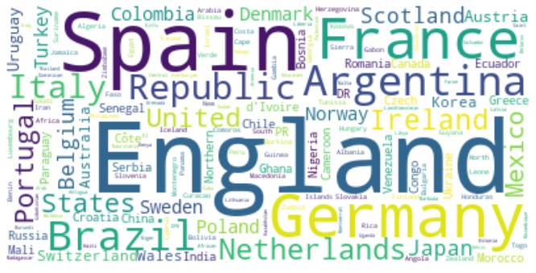

```python
from wordcloud import WordCloud, STOPWORDS
text = " ".join(nationality for nationality in fifa2.Nationality)
word_cloud = WordCloud(collocations = False, background_color = 'white').generate(text)
plt.figure(figsize = (20, 6))
plt.imshow(word_cloud, interpolation = 'bilinear')
plt.axis("off")
plt.show()
```

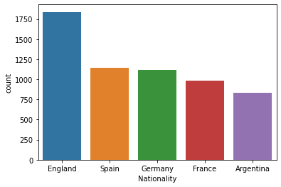

```python
sns.countplot(x="Nationality", data=fifa2, order=fifa2["Nationality"].value_counts().index[:5]);
```

The bar chart above backs up the data

### Average age of each national team in FIFA22

```
[]
```

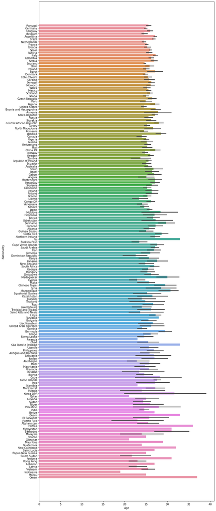

```python
plt.figure(figsize=(12,35))
sns.barplot(y=fifa2['Nationality'],x=fifa2['Age'])
plt.plot()
```

Average age of players from Oman and Eritrea teams are greater than 35, while Indonesia's is less than 20!!!!!

### Players with the highst rated skill moves including with their weak foot

```python
fifa2.loc[((fifa2['Weak Foot']==fifa2['Weak Foot'].max()) &(fifa2['Skill Moves']==fifa2['Skill Moves'].max()))]
```

|  | Name | Age | Nationality | Overall | Potential | Club | Value | Wage | Special | Preferred Foot | International Reputation | Weak Foot | Skill Moves | Work Rate | Body Type | Position | Jersey Number | Joined | Loaned From | Contract Valid Until | Height | Weight | Crossing | Finishing | HeadingAccuracy | ShortPassing | Volleys | Dribbling | Curve | … |
| --- | --- | --- | --- | --- | --- | --- | --- | --- | --- | --- | --- | --- | --- | --- | --- | --- | --- | --- | --- | --- | --- | --- | --- | --- | --- | --- | --- | --- | --- | --- |
| 64 | Neymar Jr | 29 | Brazil | 91 | 91 | Paris Saint-Germain | 129.0 | 0.270 | 2183 | Right | 5.0 | 5.0 | 5.0 | High/ Medium | Unique | LW | 10.0 | Aug 3, 2017 | NaN | 2025 | 175cm | 6 | 85.0 | 83.0 | 63.0 | 86.0 | 86.0 | 95.0 | 88.0 | … |
| 91 | J. Corona | 28 | Mexico | 82 | 82 | FC Porto | 30.5 | 0.022 | 2167 | Right | 3.0 | 5.0 | 5.0 | High/ Medium | Normal (170-185) | RW | 17.0 | NaN | NaN | NaN | 173cm | 6 | 79.0 | 66.0 | 71.0 | 82.0 | 74.0 | 85.0 | 82.0 | … |
| 1026 | O. Dembélé | 24 | France | 83 | 88 | FC Barcelona | 55.0 | 0.165 | 1990 | Left | 3.0 | 5.0 | 5.0 | High/ Medium | Unique | RW | 7.0 | Aug 28, 2017 | NaN | 2022 | 178cm | 6 | 81.0 | 75.0 | 43.0 | 78.0 | 76.0 | 89.0 | 82.0 | … |
| 1129 | Nani | 34 | Portugal | 81 | 81 | Orlando City Soccer Club | 12.0 | 0.014 | 1981 | Right | 4.0 | 5.0 | 5.0 | High/ Medium | Lean (170-185) | ST | 17.0 | Feb 19, 2019 | NaN | 2021 | 177cm | 7 | 82.0 | 73.0 | 62.0 | 82.0 | 75.0 | 86.0 | 86.0 | … |
| 2402 | Cesinha | 31 | Brazil | 75 | 75 | Daegu FC | 4.7 | 0.009 | 1902 | Right | 1.0 | 5.0 | 5.0 | High/ Medium | Normal (170-185) | RS | 11.0 | Feb 15, 2016 | NaN | 2022 | 177cm | 7 | 72.0 | 77.0 | 58.0 | 74.0 | 70.0 | 74.0 | 65.0 | … |
| 2882 | F. Ribéry | 38 | France | 79 | 79 | US Salernitana 1919 | 6.0 | 0.041 | 1880 | Right | 4.0 | 5.0 | 5.0 | Medium/ Low | Normal (170-) | CAM | 7.0 | Sep 6, 2021 | NaN | 2022 | 170cm | 7 | 74.0 | 71.0 | 41.0 | 85.0 | 79.0 | 87.0 | 83.0 | … |
| 7644 | R. Cherki | 17 | France | 73 | 88 | Olympique Lyonnais | 7.0 | 0.009 | 1712 | Left | 1.0 | 5.0 | 5.0 | High/ Low | Stocky (170-185) | SUB | 18.0 | Jul 7, 2019 | NaN | 2023 | 176cm | 7 | 70.0 | 64.0 | 28.0 | 69.0 | 57.0 | 84.0 | 77.0 | … |

## PLAYER POSITION

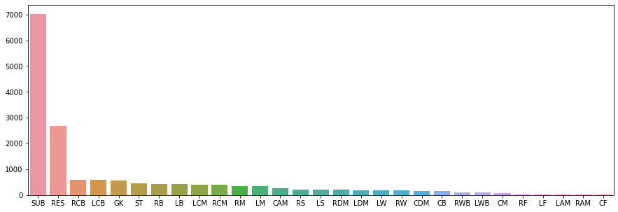

```python
fifa_pos = fifa2['Position'].value_counts()
plt.figure(figsize=(15,5))
sns.barplot(fifa_pos.index,fifa_pos.values)
plt.show()
```

No of centre forwards in the player set is the least. We can see how many of them are there in this dataset

Center Forwards are--

```python
fifa2.loc[fifa2['Position']=='CF']
```

|  | Name | Age | Nationality | Overall | Potential | Club | Value | Wage | Special | Preferred Foot | International Reputation | Weak Foot | Skill Moves | Work Rate | Body Type | Position | Jersey Number | Joined | Loaned From | Contract Valid Until | Height | Weight | Crossing | Finishing | HeadingAccuracy | ShortPassing | Volleys | Dribbling | Curve | … |
| --- | --- | --- | --- | --- | --- | --- | --- | --- | --- | --- | --- | --- | --- | --- | --- | --- | --- | --- | --- | --- | --- | --- | --- | --- | --- | --- | --- | --- | --- | --- |
| 68 | Roberto Firmino | 29 | Brazil | 85 | 85 | Liverpool | 54.000 | 0.185 | 2180 | Right | 3.0 | 4.0 | 5.0 | High/ High | Unique | CF | 9.0 | Jul 6, 2015 | NaN | 2023 | 181cm | 7 | 73.0 | 78.0 | 78.0 | 84.0 | 83.0 | 89.0 | 81.0 | … |
| 201 | K. Benzema | 33 | France | 89 | 89 | Real Madrid CF | 66.000 | 0.350 | 2116 | Right | 4.0 | 4.0 | 4.0 | Medium/ Medium | Normal (170-185) | CF | 9.0 | Jul 9, 2009 | NaN | 2023 | 185cm | 8 | 75.0 | 90.0 | 89.0 | 86.0 | 86.0 | 87.0 | 81.0 | … |
| 382 | L. Rodríguez | 36 | Argentina | 79 | 79 | Gimnasia y Esgrima La Plata | 6.000 | 0.018 | 2071 | Right | 1.0 | 4.0 | 4.0 | High/ Low | Stocky (170-) | CF | 8.0 | Jun 29, 2021 | NaN | 2022 | 168cm | 7 | 75.0 | 82.0 | 68.0 | 75.0 | 82.0 | 84.0 | 87.0 | … |
| 2134 | Deulofeu | 27 | Spain | 79 | 79 | Udinese Calcio | 18.500 | 0.022 | 1917 | Right | 3.0 | 4.0 | 4.0 | High/ Low | Normal (170-185) | CF | 10.0 | Jan 30, 2021 | NaN | 2024 | 177cm | 7 | 74.0 | 72.0 | 40.0 | 74.0 | 71.0 | 84.0 | 80.0 | … |
| 2515 | A. Büyük | 33 | Turkey | 73 | 73 | Yeni Malatyaspor | 1.900 | 0.014 | 1897 | Right | 1.0 | 3.0 | 3.0 | High/ Medium | Stocky (170-185) | CF | 10.0 | Sep 9, 2020 | NaN | 2022 | 177cm | 7 | 68.0 | 74.0 | 73.0 | 73.0 | 65.0 | 72.0 | 63.0 | … |
| 2547 | Muriqui | 35 | Brazil | 73 | 73 | Shijiazhuang Ever Bright F.C. | 1.300 | 0.007 | 1895 | Right | 2.0 | 4.0 | 3.0 | High/ Medium | Normal (170-185) | CF | 10.0 | Jan 1, 2019 | NaN | 2021 | 174cm | 6 | 65.0 | 72.0 | 65.0 | 68.0 | 66.0 | 78.0 | 67.0 | … |
| 8386 | 20 J. Ménez | 32 | France | 70 | 70 | Paris FC | 1.400 | 0.006 | 1686 | Right | 3.0 | 4.0 | 3.0 | Medium/ Low | Lean (170-185) | CF | 7.0 | Sep 26, 2019 | NaN | 2020 | 183cm | 7 | 61.0 | 65.0 | 58.0 | 74.0 | 72.0 | 77.0 | 79.0 | … |
| 9202 | H. Mahou | 21 | France | 64 | 71 | FC Lausanne-Sport | 1.200 | 0.003 | 1658 | Right | 1.0 | 3.0 | 3.0 | Medium/ Medium | Lean (170-185) | CF | 20.0 | Jun 19, 2021 | NaN | 2024 | 179cm | 7 | 62.0 | 65.0 | 49.0 | 65.0 | 57.0 | 69.0 | 55.0 | … |
| 5564 | 20 Abraham González | 33 | Spain | 66 | 66 | Tiburones Rojos de Veracruz | 0.325 | 0.003 | 1777 | Right | 1.0 | 3.0 | 3.0 | Low/ Low | Normal (170-185) | CF | 21.0 | Jul 13, 2019 | NaN | 2021 | 178cm | 8 | 68.0 | 58.0 | 45.0 | 73.0 | 50.0 | 60.0 | 73.0 | … |
| 5773 | Tan Long | 33 | China PR | 67 | 67 | Changchun Yatai FC | 0.625 | 0.004 | 1771 | Right | 1.0 | 2.0 | 4.0 | Medium/ Medium | Lean (185+) | CF | 29.0 | Jan 22, 2017 | NaN | 2021 | 185cm | 7 | 63.0 | 66.0 | 67.0 | 63.0 | 65.0 | 69.0 | 48.0 | … |

# Top 10 Tallest palyers

```python
data_height = fifa2.sort_values(['Height'],ascending=False)[:10]
data_height[['Name','Height', 'Club','Nationality']]
```

|  | Name | Height | Club | Nationality |
| --- | --- | --- | --- | --- |
| 16176 | T. Holý | 206cm | Ipswich Town | Czech Republic |
| 15358 | 20 M. Casey | 203cm | Portsmouth | England |
| 15751 | 21 C. Pantilimon | 203cm | Denizlispor | Romania |
| 14577 | P. Ndiaye | 203cm | SC Rheindorf Altach | France |
| 12448 | 20 L. Traoré | 203cm | CFR Cluj | Côte d'Ivoire |
| 15678 | A. Noppert | 203cm | Go Ahead Eagles | Netherlands |
| 13126 | F. Mulić | 203cm | Seongnam FC | Serbia |
| 12210 | 21 S. Maierhofer | 202cm | FC Würzburger Kickers | Austria |
| 15204 | C. Ezekwem | 202cm | Sportclub Verl | Germany |
| 15760 | N. Stojišić | 202cm | Vegalta Sendai | Serbia |

## Top 5 Shortest Players

```python
height = fifa2.sort_values(['Height'],ascending=True)[:5]
height[['Name','Height', 'Club','Nationality']]
```

|  | Name | Height | Club | Nationality |
| --- | --- | --- | --- | --- |
| 9791 | M. García | 155cm | Club Universidad Nacional | Mexico |
| 8218 | L. Paiva | 156cm | Club Atlético Rentistas | Uruguay |
| 7245 | N. Barrios | 156cm | San Lorenzo de Almagro | Argentina |
| 2999 | 21 J. Plata | 157cm | Deportivo Toluca | Ecuador |
| 2587 | Y. Soteldo | 158cm | Toronto FC | Venezuela |

## HEAVIEST PLAYER

```python
weight = fifa2.sort_values(['Weight'],ascending=False)[:1]
weight[['Name','Weight','Club','Nationality']]
```

|  | Name | Weight | Club | Nationality |
| --- | --- | --- | --- | --- |
| 11849 | A. Akinfenwa | 11 | Wycombe Wanderers | England |

## Potential as related to Age

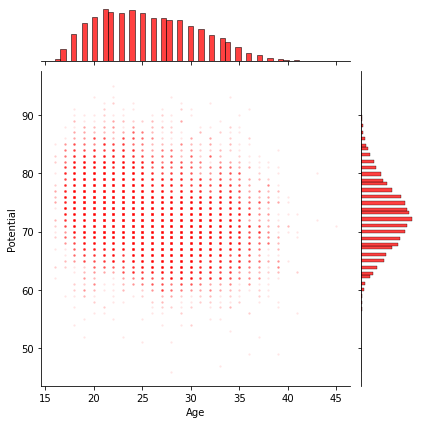

```python
sns.jointplot(x=fifa2['Age'],y=fifa2['Potential'],
              joint_kws={'alpha':0.1,'s':5,'color':'red'},
              marginal_kws={'color':'red'})
```

As it normally happens, players' potential increases from their young age and begins to decrease towards their retirement age.

## POSITION VS PLAYER VALUE

```
[]
```

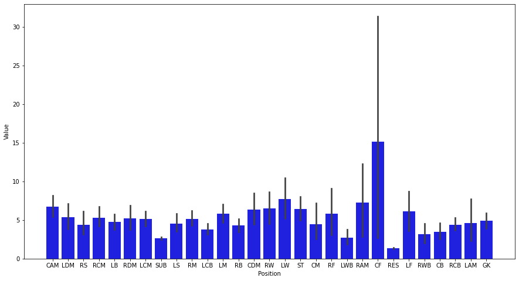

```python
plt.figure(figsize=(15,8))
sns.barplot(y=fifa2['Value'],x=fifa2['Position'], color = 'b')
plt.plot()
```

## AGILITY, AGGRESSION AND THEIR CORRELATIONS

```python
correlation = fifa2[['Crossing', 'Finishing', 'HeadingAccuracy',
       'ShortPassing', 'Volleys', 'Dribbling', 'Curve', 'FKAccuracy',
       'LongPassing', 'BallControl', 'Acceleration', 'SprintSpeed', 'Agility',
       'Reactions', 'Balance', 'ShotPower', 'Jumping', 'Stamina', 'Strength',
       'LongShots', 'Aggression', 'Interceptions', 'Positioning', 'Vision']]
```

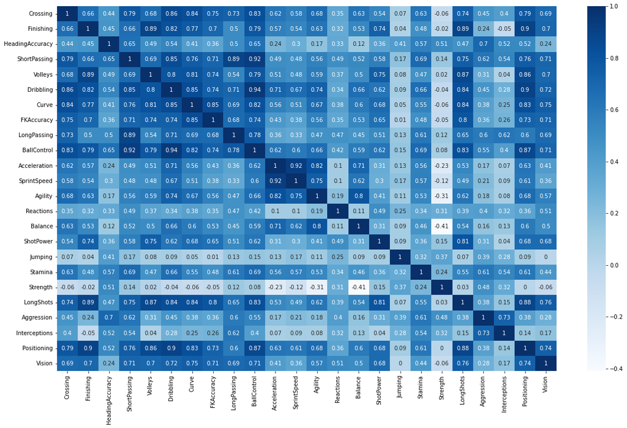

```python
plt.figure(figsize=(20,12))
sns.heatmap(round(correlation.corr(),2),annot=True,cmap='Blues')
plt.show()
```

Some highly correlated features in the dataset - `Positioning` and `Finishing` ; `Positioning` and `Dribbling`, `positioning` and `finishing`. Infact positioning is a highly correlated feature with many other features as well like - Longshots  
`Ball Control` is highly correlated with `Short Passing` and `Dribbling` `Accelaration` is highly correlated with `Sprint Speed`.

Agility is one other feature we would be interested in. We can see that `Agility` is highly correlated with `Balance`, `dribbling`, `Sprintspeed` and `Acceleration`. So you have got an important tip to know a a great footballer.

```python
correlation.sort_values(['Vision'],ascending=False)[:5]
```

|  | Crossing | Finishing | HeadingAccuracy | ShortPassing | Volleys | Dribbling | Curve | FKAccuracy | LongPassing | BallControl | Acceleration | SprintSpeed | Agility | Reactions | Balance | ShotPower | Jumping | Stamina | Strength | LongShots | Aggression | Interceptions | Positioning | Vision |
| --- | --- | --- | --- | --- | --- | --- | --- | --- | --- | --- | --- | --- | --- | --- | --- | --- | --- | --- | --- | --- | --- | --- | --- | --- |
| 29 | 85.0 | 95.0 | 70.0 | 91.0 | 88.0 | 96.0 | 93.0 | 94.0 | 91.0 | 96.0 | 91.0 | 80.0 | 91.0 | 94.0 | 95.0 | 86.0 | 68.0 | 72.0 | 69.0 | 94.0 | 44.0 | 40.0 | 93.0 | 95.0 |
| 3 | 94.0 | 82.0 | 55.0 | 94.0 | 82.0 | 88.0 | 85.0 | 83.0 | 93.0 | 91.0 | 76.0 | 76.0 | 79.0 | 91.0 | 78.0 | 91.0 | 63.0 | 89.0 | 74.0 | 91.0 | 76.0 | 66.0 | 88.0 | 94.0 |
| 244 | 85.0 | 74.0 | 51.0 | 93.0 | 66.0 | 80.0 | 85.0 | 87.0 | 90.0 | 93.0 | 67.0 | 65.0 | 79.0 | 90.0 | 90.0 | 67.0 | 53.0 | 60.0 | 60.0 | 72.0 | 53.0 | 71.0 | 83.0 | 94.0 |
| 830 | 69.0 | 77.0 | 49.0 | 92.0 | 76.0 | 85.0 | 86.0 | 79.0 | 90.0 | 91.0 | 61.0 | 59.0 | 69.0 | 74.0 | 83.0 | 78.0 | 53.0 | 75.0 | 64.0 | 76.0 | 29.0 | 59.0 | 76.0 | 92.0 |
| 422 | 83.0 | 65.0 | 72.0 | 89.0 | 85.0 | 75.0 | 74.0 | 67.0 | 90.0 | 87.0 | 53.0 | 53.0 | 68.0 | 82.0 | 82.0 | 88.0 | 64.0 | 34.0 | 63.0 | 84.0 | 87.0 | 79.0 | 83.0 | 91.0 |

Players with great `Vision` have better overalls. This is true as vision is a great technical ability which contributes to a good level of:

- Passing Accuracy
- Free kick accuracy
- positioning
- and Finishing.

```python
correlation.sort_values(['Aggression'],ascending=False)[:5]
```

|  | Crossing | Finishing | HeadingAccuracy | ShortPassing | Volleys | Dribbling | Curve | FKAccuracy | LongPassing | BallControl | Acceleration | SprintSpeed | Agility | Reactions | Balance | ShotPower | Jumping | Stamina | Strength | LongShots | Aggression | Interceptions | Positioning | Vision |
| --- | --- | --- | --- | --- | --- | --- | --- | --- | --- | --- | --- | --- | --- | --- | --- | --- | --- | --- | --- | --- | --- | --- | --- | --- |
| 1040 | 69.0 | 63.0 | 62.0 | 75.0 | 62.0 | 69.0 | 67.0 | 70.0 | 71.0 | 75.0 | 59.0 | 54.0 | 66.0 | 72.0 | 67.0 | 74.0 | 64.0 | 64.0 | 73.0 | 68.0 | 95.0 | 71.0 | 67.0 | 76.0 |
| 8508 | 40.0 | 43.0 | 67.0 | 65.0 | 35.0 | 50.0 | 38.0 | 57.0 | 52.0 | 59.0 | 34.0 | 42.0 | 49.0 | 63.0 | 40.0 | 67.0 | 80.0 | 76.0 | 87.0 | 48.0 | 95.0 | 65.0 | 48.0 | 59.0 |
| 2899 | 52.0 | 46.0 | 52.0 | 72.0 | 38.0 | 69.0 | 45.0 | 40.0 | 71.0 | 72.0 | 71.0 | 70.0 | 69.0 | 67.0 | 78.0 | 63.0 | 85.0 | 86.0 | 78.0 | 43.0 | 95.0 | 72.0 | 57.0 | 64.0 |
| 254 | 76.0 | 54.0 | 77.0 | 77.0 | 71.0 | 71.0 | 81.0 | 77.0 | 67.0 | 72.0 | 77.0 | 80.0 | 68.0 | 72.0 | 58.0 | 84.0 | 78.0 | 89.0 | 67.0 | 77.0 | 94.0 | 67.0 | 57.0 | 56.0 |
| 13248 | 60.0 | 21.0 | 40.0 | 56.0 | 13.0 | 45.0 | 42.0 | 37.0 | 55.0 | 57.0 | 57.0 | 54.0 | 53.0 | 61.0 | 70.0 | 36.0 | 61.0 | 66.0 | 85.0 | 24.0 | 94.0 | 43.0 | 41.0 | 53.0 |

Aggression is connected with interception and strength.